# Pipeline reproducible análisis de expresión diferencial

Enrique_Carnerero_Bocanegra

2025-11-13

Clarification: This code is part of a practice exercise I carried out to train differential expression analysis. It is not intended to obtain biological results or conclusions.

# 1 Differential expression analysis

## 1.1 Libraries

We will use a dataset extracted from Kaggle. This dataset contains RNA-Seq reads from the mouse hippocampus at two ages (1 month and 4 months), with three biological replicates per condition.

A quality analysis of the reads will be performed (FastQC in Galaxy), followed by gene expression quantification using Salmon, and subsequently a differential expression analysis will be carried out with DESeq2.

## 1.2 Data after quantification with Salmon

We create a tx2genes file from the annotation downloaded from gencodegenes.org and select the data that will be used.

## 1.3 Metadata

# 2 Differential expression analysis with DESeq.

```
## [1] TRUE
```

## 2.1 Exploratory data analysis of the data.

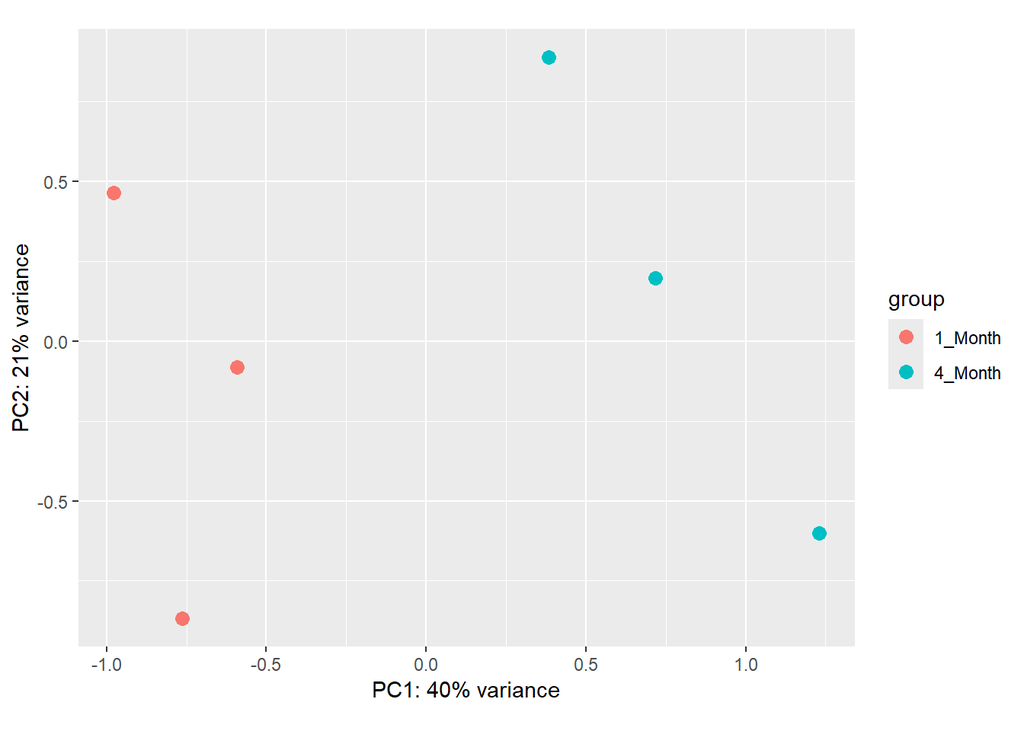

The PCA shows that the samples are well separated according to their groups, indicating that age is the main factor explaining variation in gene expression in the mouse hippocampus.

To confirm this, an exploratory heatmap is generated.

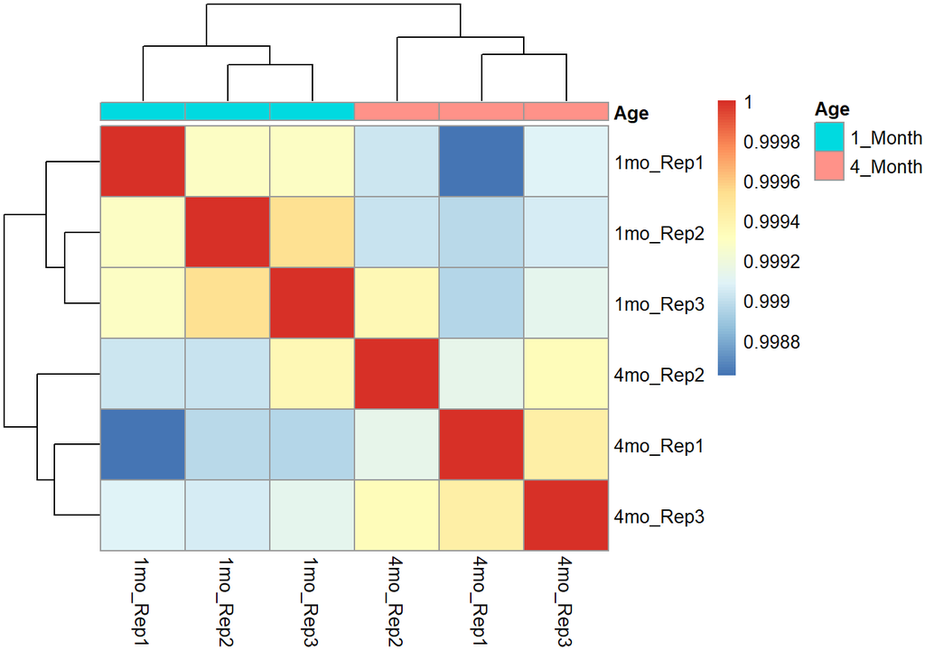

The heatmap shows that the groups defined by the metadata are well separated, indicating that the age is the main factor driving the differential gene expression in our region. The colors indicate high levels in the correlation within each group, showing excellent biological reproducibility and technical consistency between samples.

## 2.2 Run DESeq2 differential expression analysis

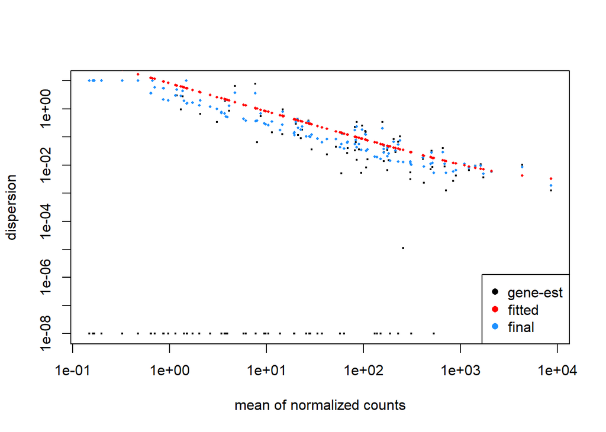

## 2.3 Contrast between 1_month and 4_month

## 2.4 Main results

Five genes are found to be differentially expressed in 4-month-old mice compared to 1-month-old mice.

## 2.5 Aditional visualizations

### 2.5.1 Volcano Plot

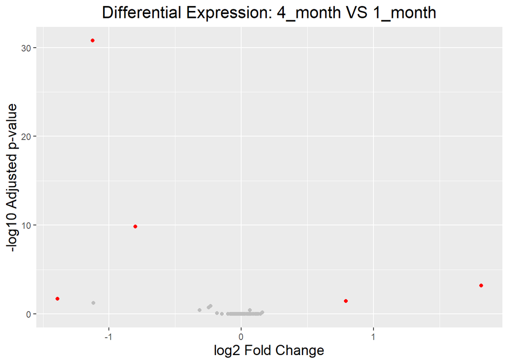

### 2.5.2 Heatmap

```
## [1] "X1mo_Rep1" "X1mo_Rep2" "X1mo_Rep3" "X4mo_Rep1" "X4mo_Rep2" "X4mo_Rep3"
```

```
## [1] "1mo_Rep1" "1mo_Rep2" "1mo_Rep3" "4mo_Rep1" "4mo_Rep2" "4mo_Rep3"
```

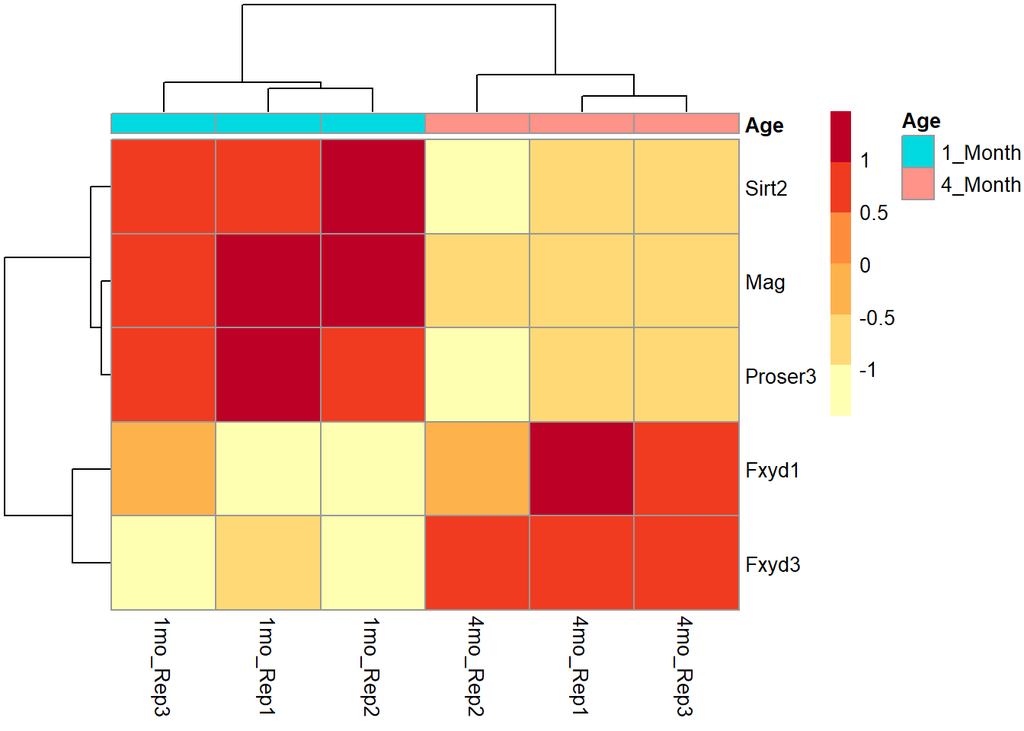

Genomic annotation studies were performed for the analysis of the differentially expressed genes.

## 2.6 Gene Annotation (GSEA)

```
## AnnotationHub with 87 records
## # snapshotDate(): 2024-10-28
## # $dataprovider: Ensembl
## # $species: Mus musculus, Mus musculus musculus, Mus musculus domesticus, Mu...
## # $rdataclass: EnsDb
## # additional mcols(): taxonomyid, genome, description,
## #   coordinate_1_based, maintainer, rdatadateadded, preparerclass, tags,
## #   rdatapath, sourceurl, sourcetype
## # retrieve records with, e.g., 'object[["AH53222"]]'
##
##              title
##   AH53222  | Ensembl 87 EnsDb for Mus Musculus
##   AH53726  | Ensembl 88 EnsDb for Mus Musculus
##   AH56691  | Ensembl 89 EnsDb for Mus Musculus
##   AH57770  | Ensembl 90 EnsDb for Mus Musculus
##   AH60788  | Ensembl 91 EnsDb for Mus Musculus
##   ...        ...
##   AH116906 | Ensembl 112 EnsDb for Mus musculus
##   AH116907 | Ensembl 112 EnsDb for Mus musculus musculus
##   AH116908 | Ensembl 112 EnsDb for Mus musculus domesticus
##   AH116909 | Ensembl 112 EnsDb for Mus musculus
##   AH119358 | Ensembl 113 EnsDb for Mus musculus
```

```
## [1] 50
```

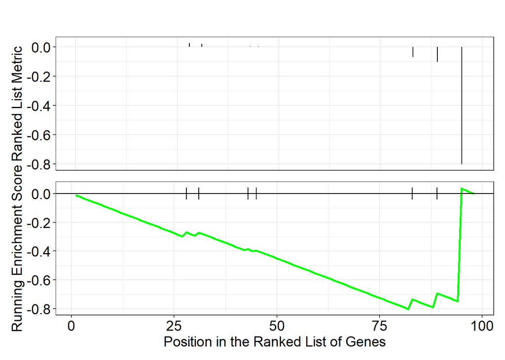

There are no results with an adjusted p-value of 0.05, which is required for significance, so it will be increased to 0.5, even though the results are not truly significant, as this is a practice exercise.

Note: For biologically and statistically meaningful results, the adjusted p-value should be 0.05 or lower.

The GO analysis will also be performed using a p-value cutoff of 0.5 for practice purposes.

## 2.7 Gene Annotation (GO) -> Biological Process

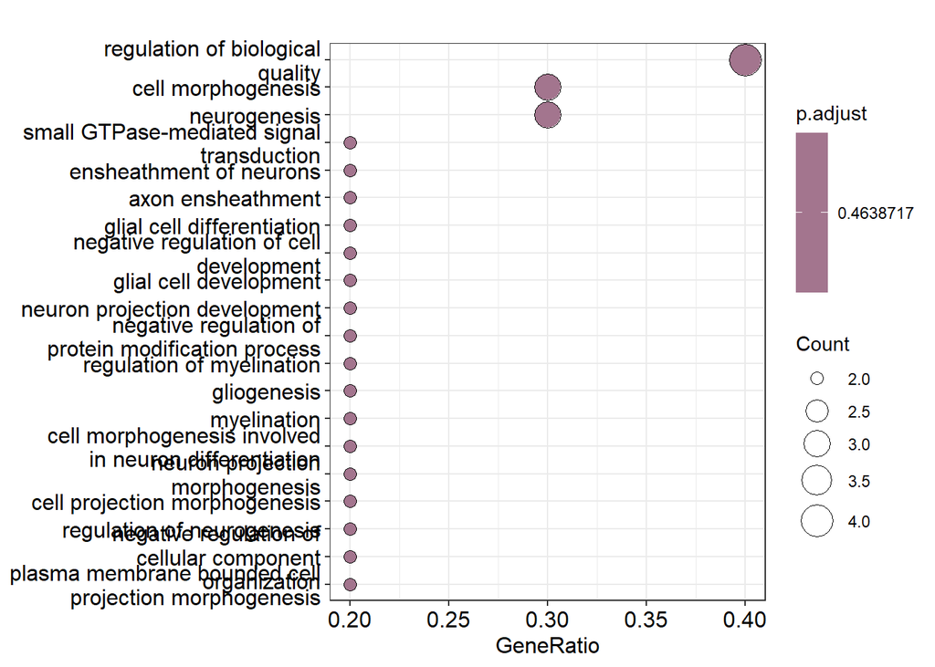

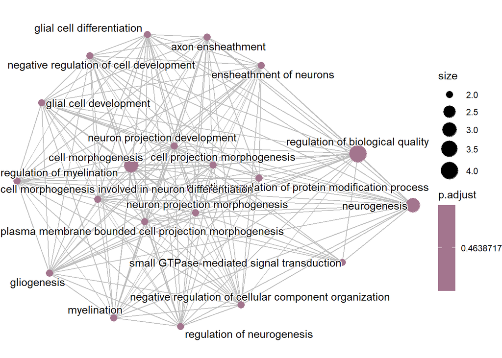

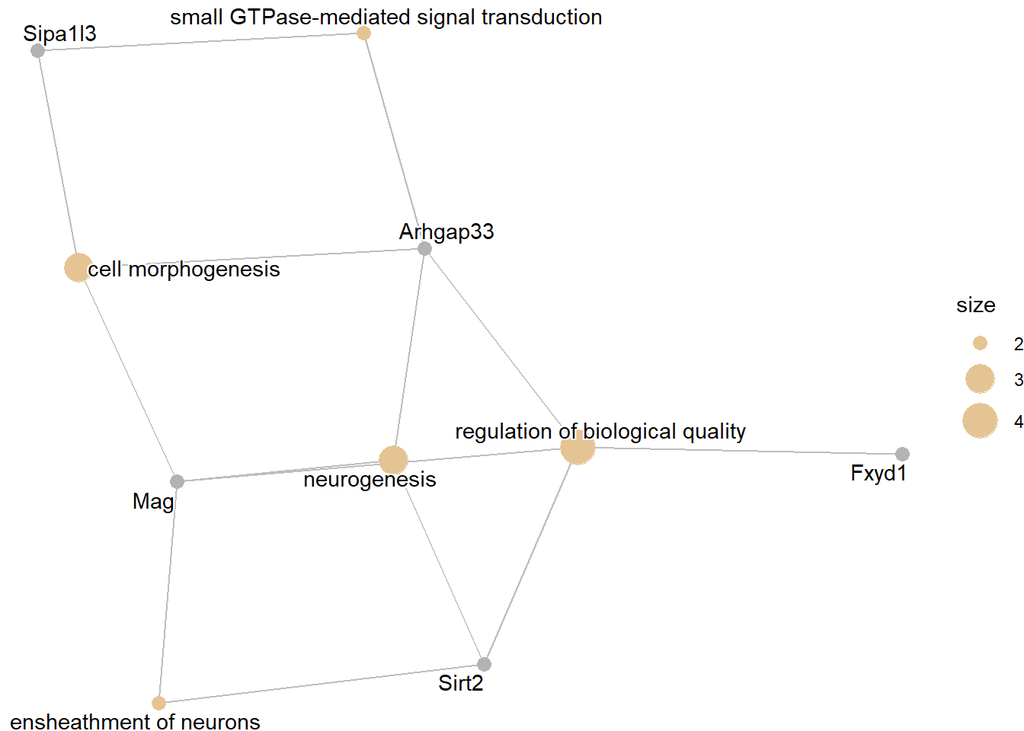

## 2.8 Gene Annotation (GO) -> Molecular Function

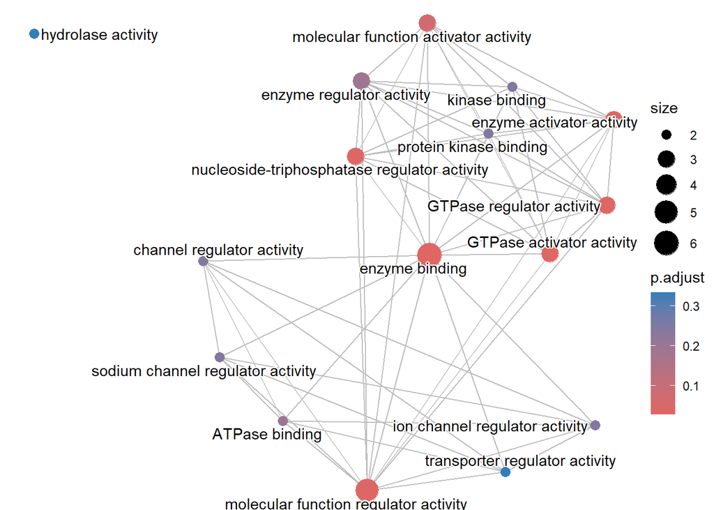

## 2.9 Gene Annotation (GO) -> Cellular Component

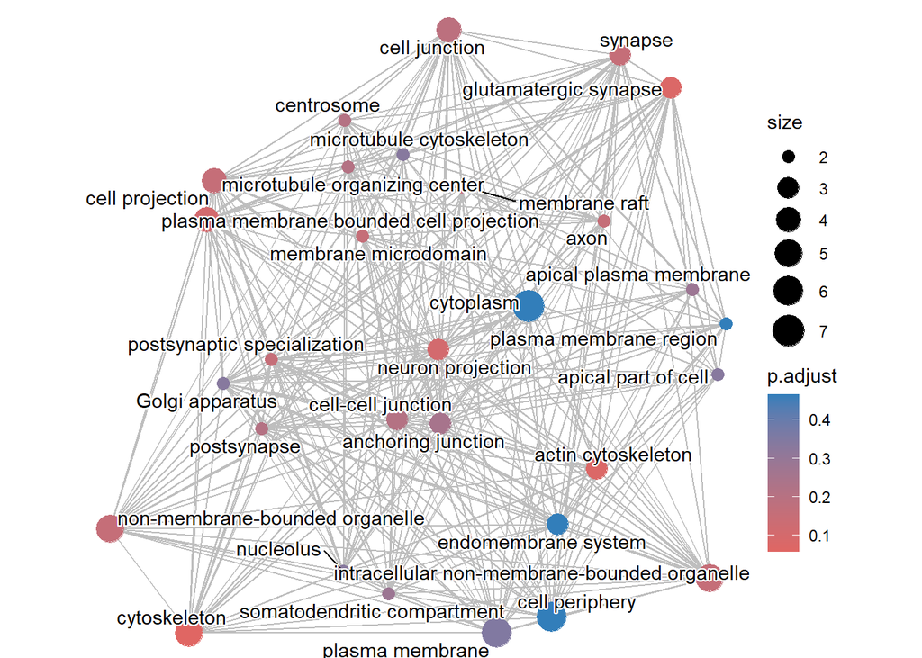